# DOSCHEDA Manual

Bruno Contrino & Piero Ricchiuto

## DOSCHEDA Manual

DOSCHEDA is a Shiny web application that analyses Chemoproteomics Mass Spectrometry data. It is designed for minimal user input and requires no programming skills. The application has a series of different pipelines which will be applicable to different experimental designs. A novel aspect of DOSCHEDA is a peptide removal process aimed to reduce noise in the data, given that the data supplied is peptide intensities. This process will be explained in detail within the manual. The application allow users to apply linear and sigmoidal models for data analysis, see Figure 1. After running DOSCHEDA, the user can download and visualize the results in a self-contained HTML report format which contains all of the relevant plots seen whilst DOSCHEDA is running. This manual will aim to give a general overview of the application, for specific, step-by-step instructions for a given experimental design please refer to the DOSCHEDA walkthroughs which follow the manual at in this document and are also available at https://github.com/brunocontrino/DOSCHEDA_APP.

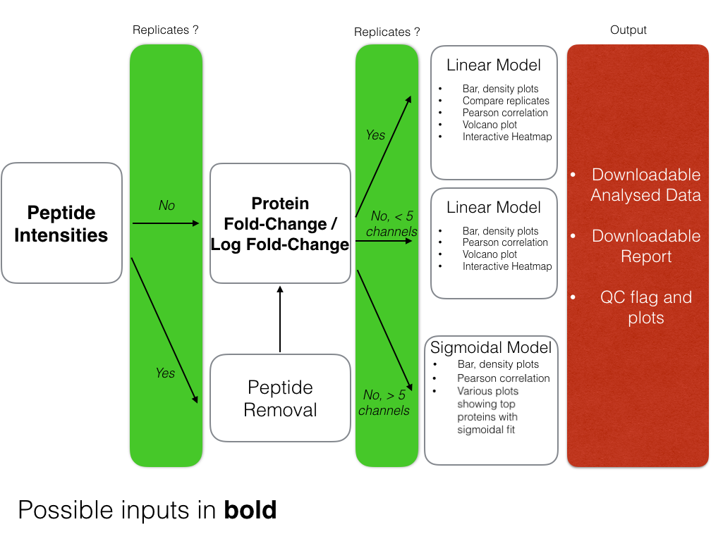

Figure 1. Workflow of DOSCHEDA application

### The Data

The application is designed to take three different types of data obtained from a typical Chemoproteomics experiment:

**Peptide Intensities:** These consist of a series of peptide intensities which are attributed to each protein in the data set. We use the same procedure for summing the reporter ions to protein relative quantification as described in Proteome Discoverer 2.1. The protein fold changes are then converted to log2 scale and then passed into the pipeline.

**Fold Changes:** These are the fold changes of the protein intensities.

**Log Fold Changes:** These are the log fold changes of the protein intensities mentioned above.

This application has been optimised for using data from Proteome Discoverer 2.1 (PD 2.1), but it can also take data from other software given that it contains specific columns. In fact, depending on which type of input data is selected there are different inputs that the application need for downstream processing as described in Table 1 and Table 2.

Table 1. Required inputs for DOSCHEDA if data is from PD2.1

|  | Input |
| --- | --- |
| **Peptide Intensities** | Peptide Qvality Score, Protein Accessions, Peptide Names, Intensities |
| **Fold Changes** | Protein Fold Changes |
| **Log-Fold Changes** | protein Log-Fold Changes |

Table 2. Required inputs for DOSCHEDA if data is not from PD2.1

|  | Input |
| --- | --- |
| **Peptide Intensities** | Peptide Qvality Score, Protein Accessions, Peptide Names, Intensities |
| **Fold Changes** | Protein Accessions, protein Fold Changes, Gene id(optional), Unique Peptides |
| **Log-Fold Changes** | Protein Accessions, protein Log-Fold Changes, Gene id (optional), Unique Peptides |

### Uploading your data

To use DOSCHEDA correctly it is key to learn how the **Data Upload** tab is used for data upload, including the correct selection of column headers and adequate input data for the selected analysis. In this section, we give an overall guide on how to do this.

**Step 1**. Click on the **Upload Data** tab.

**Step 2**. Choose your data type (intensities, Fold changes, Log Fold Changes)

**Step 3**. Choose your file type (csv,txt,xlsx)

**Step 4**. Click ‘Browse’ and select your file. Ensure the prior steps have been completed.

**Step 5**. Once the file has loaded go to the drag and drop box and enter the correct columns which contain your input intensities or fold changes.

**Step 6**. Check that the selected columns correspond to the correct standardised name by looking at the table in the top right corner. + If the user is applying a sigmoidal model, select **Sigmoidal** from the **Fit model:** radio buttons and input your concentrations. They must be in a non-log form and the should be from lowest to highest, each separated by comma.

**Step 7**. If your data is from PD2.1 click away from the ‘Data Upload’ tab and cycle through the rest of the tabs, when DOSCHEDA is busy, the word ’loading will appear in the top left corner of the app and once this stops the plots will be generated. If data inputs are not obtained from PD2.1 the user will need to enter the missing fields as described in Table 2 by ticking the appropriate checkboxes and selecting the correct column names for these fields.

### Other Uploadable Files

There are two other possible upload files that DOSCHEDA has a functionality for, a protein accession to gene symbol ID (two columns file) and a list of custom gene symbol IDs (e.g. Kinases “CDK9”) to compare with the pull-down proteome in your data, the default is a list of kinases that have been taken from the literature.

DOSCHEDA uses Intermine to map Uniprot accession number to gene symbol ID. Should the user wish to by-pass DOSCHEDA mapping it can be done by uploading a custom 2 columns file (accession to gene symbol ID). Intermine files are updated regularly and should be able to provide the user with the most up-to-date conversions.

The **Include file** check box visible in the Venn tab within the **Box and Density plots** tab will simply let the user visualise the intersection between the uploaded custom list of proteins and the pull-down proteome in your data. This is not crucial to the DOSCHEDA pipeline and should only be used if the user has this specific requirement.

### Downloading your Results

From the ‘Downloads’ tab users can save their processed data by clicking on the ‘Download Data’ button. Also in the same tab, the ‘Download Report’ button enables users to download an HTML report containing all the plots seen in the analysis with descriptions as well as other important information such as the options the user has used during the workflow including the number of channels (e.g. concentrations), replicates and the statistical fit applied for the data analysis.

### Normalisation Step

The user has also the option to scale or normalise the protein fold changes with a simple median fold change normalisations or local regression (LOESS) normalisation, respectively. The normalisation step can also be skipped if the user has already pre-normlised data.

The LOESS in DOSCHEDA is calculated with the loess.normalize function of the affy package in R. LOESS has been shown compared to other methods that performs systematically well in the differential expression analysis. (Tommi Välikangas et al. Brief Bioinformatics 2016).

The median fold change normalisation is a simple function we developed in DOSCHEDA that computes the median of each column of the input data and this is used to divide each protein fold change of the corresponding column from which the median was derived. The median fold change normalisation scales each condition to its median and it would simply move the data so that the median difference is 0 and it will not correct for any non-linear bias.

### Different Models

DOSCHEDA has the option to apply two different types of model to the data, linear and sigmoidal. The linear model uses a linear model fit with a quadratic formula such that the coefficients intercept, slope and quadratic of a parabola can be extracted. This fit can be applied to experiments with few concentrations (e.g. 3 to 5).  
However, if there are enough channels (e.g. concentrations), a sigmoidal fit can be applied. DOSCHEDA uses a model with 4 parameters to model a dose response for each protein.

Table 3. Possible model application depending on experimental design.

[output not shown]

### Linear Fit: Peptide Removal Process

The peptide removal process uses a Pearson Moment Correlation coefficient in order to determine linearity between two of the same peptides that belong to the same protein accession. We assume that the same peptide has a linear relationship between each replicate at the different concentrations, this grounds our reasoning for using a Pearson Correlation to quantify the linear relationship between the replicates.

The main steps of the peptide removal are as follows:

**Step 1**. Match the master protein name in both replicates.

**Step 2**. Match the peptides within each master protein name.

**Step 3**. For each peptide within the same master protein, if the number of peptides differs between replicates, the algorithm will match them to the highest number of peptides. The introduced new peptides will have the mean intensities computed from the replicate with the lowest number of peptides. The imputed mean values are only used in step 4 to allow the correlation calculation, but are not considered in the final quantification of the protein. See Example below.

**Step 4**. Per peptide, calculate the Pearson correlation between each replicate and eliminate all peptides with a coefficient less than 0.4.

**Step 5**. Sum all intensities per master protein name to give a final intensity per protein.

### Example of Step 3

This example is to clarify the details of step 3. Let there be two replicates: one with three peptide intensities (Table 4) and one with two (Table 5), for the same peptide. To match the number of total peptides (three) between the two replicates the algorithm will introduce in the replicate with less peptides (Table 5) an extra peptide whose intensities are the mean values of each channel within the same replicate. The result is reported in the third row of Table 6. The two tables are then used to calculate the Pearson moment correlation constant, if it is smaller than 0.4 the peptide will not be used for the final protein quantification. In this case the correlation constant is 0.5 therefore, the peptide A will be used in the quantification of its associated master protein.

Table 4: Example: Peptide values for replicate one

| Peptide | Control_rep1 | C0_rep1 | C1_rep1 | C2_rep1 |
| --- | --- | --- | --- | --- |
| A | 1 | 1 | 1 | 1 |
| A | 2 | 2 | 2 | 2 |
| A | 3 | 3 | 3 | 3 |

Table 5: Example: Peptide values for replicate two

| Peptide | Control_rep2 | C0_rep2 | C1_rep2 | C2_rep2 |
| --- | --- | --- | --- | --- |
| A | 1 | 1 | 1 | 1 |
| A | 2 | 2 | 2 | 2 |

Table 6: Example: New values for replicate two, with the third row being the mean of the columns.

| Peptide | Control_rep2 | C0_rep2 | C1_rep2 | C2_rep2 |
| --- | --- | --- | --- | --- |
| A | 1 | 1 | 1 | 1 |
| A | 2 | 2 | 2 | 2 |
| A | 1.5 | 1.5 | 1.5 | 1.5 |

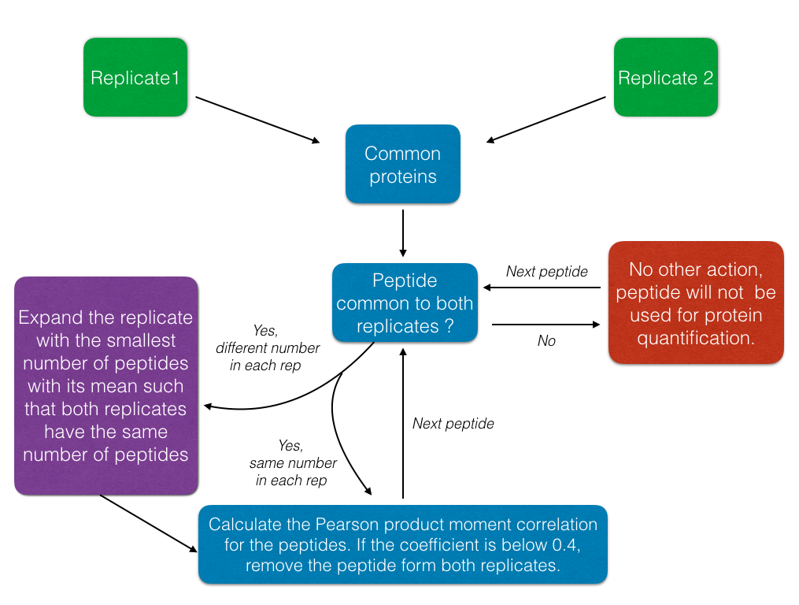

Figure 2. Peptide removal process workflow

### Sigmoidal Fit: Parameters

The pipeline for analysing a data set with a sigmoidal fit is slightly different than in the linear model case. The data is not transformed to log2 as each channel is converted from fold-change to percentages.

DOSCHEDA will fit a sigmoidal with 4 parameters (top, bottom, RB50, slope) as described in Dose-Response Analysis Using R Christian Ritz et al (2015) Plos One. The RB50 is the concentration of the drug where the 50% of the protein has bound to the drug. In residual binding experiments the slope coefficient is expected to be negative as we expect a decrease between the initial value (no binding) and final value (bounded protein to the drug) of each protein.

If the data set contains a pull down of pull down column, the depletion factor *r* of the experiment can be calculated. This is then multiplied by the RB50 value to give the dissociation constant (K<sub>d</sub>) which is the equilibrium rate constant of the protein. As described by Daub et al. (2015) Quantitative Proteomics of Kinase Inhibitor Targets and Mechanisms.

The user can include this in the final downloadable data by ticking the **Include pulldown of pulldown** check box in the **Data Upload** tab which will allow you include this column. DOSCHEDA will compute the depletion factor *r* and the dissociation constant (K<sub>d</sub>) which will be reported in the downloadable data.

### The Plots

The plots that will be generated are designed for quality check purposes and visualise the result outcomes of the statistical analysis.

Table 7: DOSCHEDA plots and their use to the pipeline.

| Plot | Description | Available | Type |
| --- | --- | --- | --- |
| Box | A box plot showing the mean and the interquartile range of each normalised channel. For linear fits this is log2 normalised fold changes, for sigmoidal percentages. | Always | QC |
| Density and ranked protein | These plots show the density distribution of each channel and the distribution of the ranked proteins | Always | QC |
| Venn | The intersection of the kinome and the inputted proteins. There is also the option to load a list of protein names and see the intersection with a personalised list | Always | QC |
| MeanSD | Shows the ranked means with a running median calculated with a window size of 10% | Always | QC |
| Mean vs Difference | Shows us the mean protein fold change and difference between different replicates | At least 2 replicates | QC |
| Corrgram | Pearson Correlation Coefficient between each channel | Always | QC |
| Compare Replicates | The fold change per protein plotted against each other in each replicate | At least 2 replicates | Analysis |
| PCA | Each channel is plotted in the first two principal components of the data | Always | Analysis |
| Heatmap | Interactive heatmap of the values per protein per channel | Always | Analysis |
| Linear Model: P-values | The distribution of p-values for each coefficient of the linear model, that is the intercept, slope and quadratic | Linear Model Applied | Analysis |
| Linear Model: volcano plots | The distribution of proteins by their mean and standard deviation coloured by their p-values, there is a plot for each coefficient in the linear model | Linear Model Applied | Analysis |
| Sigmoidal Model: Top - Bottom | The largest differences between the proteins from the lowest and highest concentrations | Sigmoidal Model Applied | Analysis |
| Sigmoidal Model: RB50 | The top proteins with significant RB50 values | Sigmoidal Model Applied | Analysis |
| Sigmoidal Model: Slopepl | The top proteins with significant Slope Value | Sigmoidal Model Applied | Analysis |

### DOSCHEDA: Summary tab

The summary tab in the app will show a few quality controls and show a table of the most relevant values for each gene in the pipeline. The user can search this table with text matching.

There are also boxes which, depending on your results, will either show a green box with a tick if your results meet some criteria and an orange warning box if the criteria are not met.

Table 8: DOSCHEDA Quality Control flags in the summary section.

| QC | Criteria |
| --- | --- |
| Corrgram | Corrgram: No channels are anti-correlated |
| Model Coefficients | The number of statistically significant coefficients are greater than 0 for each coefficient |

### Get DOSCHEDA

There are two different methods to use DOSCHEDA:

1. Use a web link https://doscheda.shinyapps.io/doscheda/ , and have the user data files on the device from which DOSCHEDA is accessed from.
2. Download the App from github at https://github.com/brunocontrino/DOSCHEDA

Note:

For option 2 one must have R installed on their device as well as the packages that are present at the top of the app.R file seen in the github repository.

### Help and Troubleshooting

Please feel free to contact us at piero.ricchiuto@astrazeneca.com for feedbacks or unexpected isssues.

##### Wrong file type selected for upload.

If the user has selected the wrong file type by mistake, DOSCHEDA will show a series of errors in the ‘Data Upload’ section. To rectify this one must select a different file to upload, make sure that the file type is selected, then re-click on the ‘Browse’ button and select the required file. The application will now work as it should.

##### Error: variable lengths differ

If this error is present when applying a sigmoidal fit to the data, this means that DOSCHEDA is expecting a different amount of concentrations, please return to the **Data Upload** tab and ensure that this section has been filled in correctly, note that there will be a warning below the concentration input to tell the user if it is expecting more or less concentrations.

### References

The following are references for the packages used in DOSCHEDA.

Dan Carr, ported by Nicholas Lewin-Koh, Martin Maechler and contains copies of lattice functions written by Deepayan Sarkar (2015). hexbin: Hexagonal Binning Routines. R package version 1.27.1. https://CRAN.R-project.org/package=hexbin

Venables, W. N. & Ripley, B. D. (2002) Modern Applied Statistics with S. Fourth Edition. Springer, New York. ISBN 0-387-95457-0

Winston Chang, Joe Cheng, JJ Allaire, Yihui Xie and Jonathan McPherson (2016). shiny: Web Application Framework for R. R package version 0.14.2. https://CRAN.R-project.org/package=shiny

Winston Chang (2016). shinydashboard: Create Dashboards with ‘Shiny’. R package version 0.5.3. https://CRAN.R-project.org/package=shinydashboard

Hadley Wickham (2016). stringr: Simple, Consistent Wrappers for Common String Operations. R package version 1.1.0. https://CRAN.R-project.org/package=stringr

Gautier, L., Cope, L., Bolstad, B. M., and Irizarry, R. A. 2004. affy—analysis of Affymetrix GeneChip data at the probe level. Bioinformatics 20, 3 (Feb. 2004), 307-315.

Ritchie, M.E., Phipson, B., Wu, D., Hu, Y., Law, C.W., Shi, W., and Smyth, G.K. (2015). limma powers differential expression analyses for RNA-sequencing and microarray studies. Nucleic Acids Research 43(7), e47.

Yihui Xie (2016). DT: A Wrapper of the JavaScript Library ‘DataTables’. R package version 0.2. https://CRAN.R-project.org/package=DT

H. Wickham. ggplot2: Elegant Graphics for Data Analysis. Springer-Verlag New York, 2009.

Wolfgang Huber, Anja von Heydebreck, Holger Sueltmann, Annemarie Poustka and Martin Vingron. Variance Stabilization Applied to Microarray Data Calibration and to the Quantification of Differential Expression. Bioinformatics 18, S96-S104 (2002).

Baptiste Auguie (2016). gridExtra: Miscellaneous Functions for “Grid” Graphics. R package version 2.2.1. https://CRAN.R-project.org/package=gridExtra

Sarkar, Deepayan (2008) Lattice: Multivariate Data Visualization with R. Springer, New York. ISBN 978-0-387-75968-5

Kevin Wright (2016). corrgram: Plot a Correlogram. R package version 1.9. https://CRAN.R-project.org/package=corrgram

Jan Graffelman (2013). calibrate: Calibration of Scatterplot and Biplot Axes. R package version 1.7.2. https://CRAN.R-project.org/package=calibrate

Hadley Wickham (2007). Reshaping Data with the reshape Package. Journal of Statistical Software, 21(12), 1-20. URL http://www.jstatsoft.org/v21/i12/.

Hadley Wickham (2016). readxl: Read Excel Files. R package version 0.1.1. https://CRAN.R-project.org/package=readxl

Hadley Wickham (2016). lazyeval: Lazy (Non-Standard) Evaluation. R package version 0.2.0. https://CRAN.R-project.org/package=lazyeval

Ritz, C., Baty, F., Streibig, J. C., Gerhard, D. (2015) Dose-Response Analysis Using R PLOS ONE, 10(12), e0146021

Hadley Wickham (2016). httr: Tools for Working with URLs and HTTP. R package version 1.2.1. https://CRAN.R-project.org/package=httr

Jeroen Ooms (2014). The jsonlite Package: A Practical and Consistent Mapping Between JSON Data and R Objects. arXiv:1403.2805 [stat.CO] URL http://arxiv.org/abs/1403.2805

JJ Allaire, Joe Cheng, Yihui Xie, Jonathan McPherson, Winston Chang, Jeff Allen, Hadley Wickham, Aron Atkins and Rob Hyndman (2016). rmarkdown: Dynamic Documents for R. R package version 1.1. https://CRAN.R-project.org/package=rmarkdown

Hadley Wickham and Romain Francois (2016). dplyr: A Grammar of Data Manipulation. R package version 0.5.0. https://CRAN.R-project.org/package=dplyr

Joe Cheng and Tal Galili (2016). d3heatmap: Interactive Heat Maps Using ‘htmlwidgets’ and ‘D3.js’. R package version 0.6.1.1. https://CRAN.R-project.org/package=d3heatmap

Thomas A. Gerds (2015). prodlim: Product-Limit Estimation for Censored Event History Analysis. R package version 1.5.7. https://CRAN.R-project.org/package=prodlim